# 6200_A2

Author

Zimo Yang

Published

November 10, 2024

## Libraries

```r
library(dplyr)
library(tidyverse)
library(httr)
library(xml2)
library(rvest)
library(geodata)
library(raster)
library(sf)
library(terra)
library(tmap)
library(coin)
```

# Q1: Web scraping 2012-2017 data

```r
html <- read_html("https://www2.gov.bc.ca/gov/content/safety/wildfire-status/about-bcws/wildfire-statistics")

#After checking the source code, I found that the 2012-2017 data are stored in a table
data_1217<- html |>
  html_node("table") |>
  html_table()
```

## 1.1 Data Preprocessing

```r
#Get a sense of the data structure and data types
#summary(data_1217)
#str(data_1217)

#Handling missing data
#colSums(is.na(data_1217))          # No missing data

#Handling duplicates
#sum(duplicated(data_1217))        # No duplicates

# Format Date
data_1217$`Discovery Date` <- as.Date(trimws(data_1217$`Discovery Date`), format = "%B %d, %Y")

# Format Longitude and Latitude
# Function to convert DMM to decimal degrees
convert_dmm_to_dd <- function(dmm) {
  degrees <- as.numeric(sub(" .*", "", dmm))  # Extract degrees
  minutes <- as.numeric(sub("^[0-9]+ ", "", dmm))  # Extract minutes
  return(degrees + (minutes / 60))
}

# Apply the function to Latitude and Longitude, negating Longitude for western hemisphere
data_1217$Latitude <- convert_dmm_to_dd(data_1217$Latitude)
data_1217$Longitude <- -convert_dmm_to_dd(data_1217$Longitude)

#Handling outliers
#summary(data_1217)

# Size (ha) and Discorver Date need to be examined
#summary(data_1217$`Size (ha)`)
#boxplot(data_1217$`Size (ha)`, main="Distribution of Size")

#summary(data_1217$`Discovery Date`)
#boxplot(data_1217$`Discovery Date`, main="Distribution of Discovery date")

# Filter the data to include only dates between January 1, 2012, and December 31, 2017
data_1217 <- data_1217 |>
  filter(`Discovery Date` >= as.Date("2012-01-01") & `Discovery Date` <= as.Date("2017-12-31"))
```

## 1.2 Answer:

1. There is no missing value and duplicate data in the data set.
2. There are some outliers for the variable Size (ha). For example, the maximum of size is 521012 Hectares. However, as I searched online, this is a valid record happened in 2017. So, I will not remove these outliers because extreme weather events are the key areas of study.
3. There are some outliers for the variable Discovery Dates, since this data set only include data from 2012-2017, I will remove the outlier dates.

# Q2 Pull temperature and elevation data for B.C using the geodata package.

## 2.1 Extract B.C. Boundary

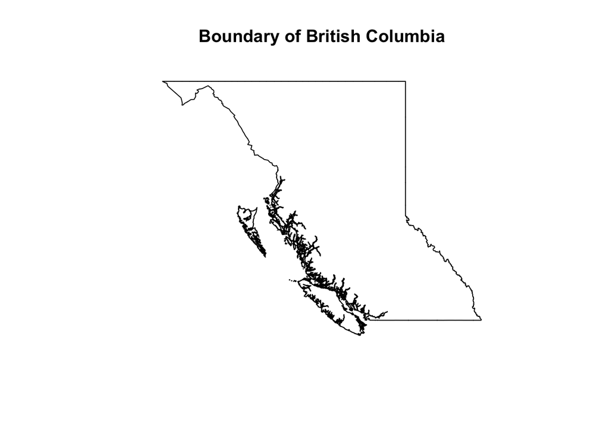

```r
# Download level 1 administrative boundaries for Canada
canada_boundaries <- gadm(country = "CAN", level = 1, path = tempdir())

# Extract the boundary for British Columbia
bc_boundary <- canada_boundaries[canada_boundaries$NAME_1 == "British Columbia", ]

# Convert to 'sf' object
bc_boundary_sf <- st_as_sf(bc_boundary)

# Convert to a 'SpatVector' object for terra compatibility
bc_boundary_vect <- vect(bc_boundary_sf)

# Plot the boundary to check
plot(st_geometry(bc_boundary_sf), main = "Boundary of British Columbia")
```

## 2.2 Crop and Mask Temperature Data

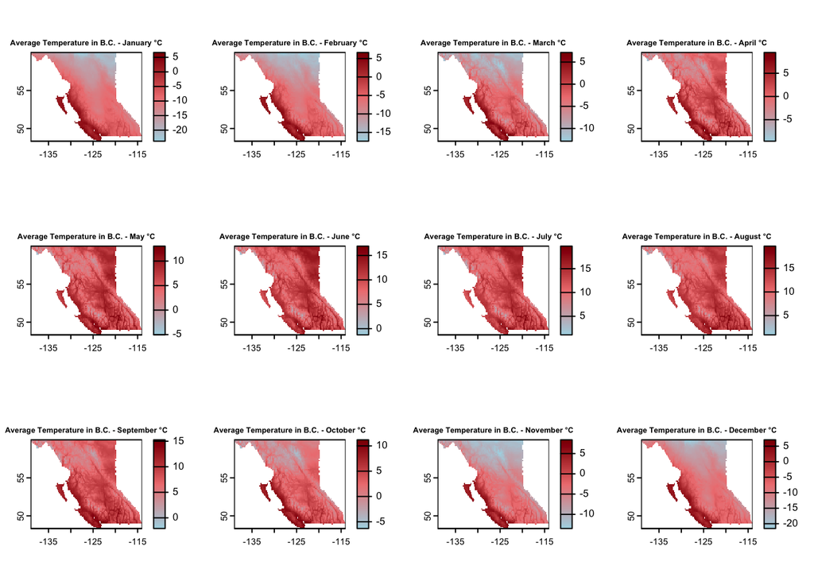

```r
bc_extent <- extent(st_bbox(bc_boundary_sf))

# Download WorldClim temperature data as a SpatRaster
temp_data <- geodata::worldclim_global(var = "tavg", res = 10, path = tempdir())

# Crop and mask temperature data to the extent of B.C.
temp_data_bc <- crop(temp_data, bc_boundary_vect)
temp_data_bc <- mask(temp_data_bc, bc_boundary_vect)

# take a look of the temperature data set
#summary(temp_data_bc)
#str(temp_data_bc)

#Rename the column
# Rename the layers to represent each month
names(temp_data_bc) <- c("January", "February", "March", "April", "May", "June",
                         "July", "August", "September", "October", "November", "December")
#summary(temp_data_bc)

# Verify the structure
#print(temp_data_bc)  # Should display details of a 12-layer object

# Set up a 3x4 grid layout for the 12 monthly plots
par(mfrow = c(3, 4), mar = c(2, 2, 2, 2))  # mfrow defines the grid (3 rows, 4 columns), mar sets margins

# Define month names
month_names <- c("January", "February", "March", "April", "May", "June",
                 "July", "August", "September", "October", "November", "December")

# Create a blue-to-red color palette
color_palette <- colorRampPalette(c("lightblue", "lightcoral", "darkred"))

# Loop through each month and plot
for (i in 1:12) {
  if (!is.null(temp_data_bc[[i]])) {  # Check if the layer exists
    plot(temp_data_bc[[i]],
         main = paste("Average Temperature in B.C. -", month_names[i], "°C"),
         cex.main = 0.6,  # Set a smaller font size for the title
         col = color_palette(100))  # Use 100 colors in the gradient
  } else {
    message(paste("Layer for", month_names[i], "is missing."))
  }
}
```

```r
# Reset plotting parameters to default
par(mfrow = c(1, 1))
```

# 2.3 Answer

After examining the temperature data in B.C., it looks like there are no obvious outliers. However, there are many missing data. Given the special nature of sf object, I will not delete any of the missing data.

## 2.4 Crop and Mask Elevation Data

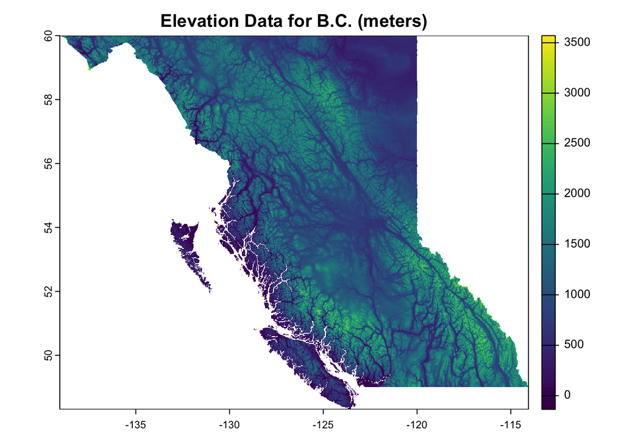

```r
# Download elevation data as a SpatRaster
elevation_data <- geodata::elevation_30s(country = "CAN", path = tempdir())

# Crop and mask elevation data to the extent of B.C.
elevation_data_bc <- crop(elevation_data, bc_boundary_vect)
elevation_data_bc <- mask(elevation_data_bc, bc_boundary_vect)

#Take a look of the data set
#summary(elevation_data_bc)
# Plot the cropped elevation data with unit in the title
plot(elevation_data_bc, main = "Elevation Data for B.C. (meters)")
```

# 2.5 Answer

After examining the elevation data in B.C, it looks like there are no obvious outliers. However, there are many missing data. Given the special nature of sf object, I will not delete any of the missing data.

# Q3 Visualize wildfires over time between 2012-2017 overtop a temperature raster.

## 3.1 Data Preparation

```r
# Ensure the Date column is in Date format
data_1217$`Discovery Date` <- as.Date(data_1217$`Discovery Date`, format = "%Y-%m-%d")

# Extract the month as a two-digit string (e.g., "04" for April)
data_1217$Month <- format(data_1217$`Discovery Date`, "%m")

# Format month as two-digit strings
data_1217$Month <- sprintf("%02d", as.numeric(data_1217$Month))

# Convert wildfire data to sf object
wildfire_sf <- st_as_sf(data_1217, coords = c("Longitude", "Latitude"), crs = 4326)

# Create a list to hold wildfire data for each month
wildfire_sf_list <- vector("list", 12)

# Filter wildfire data for each month
for (i in 1:12) {
  wildfire_sf_list[[i]] <- wildfire_sf %>% filter(Month == sprintf("%02d", i))
}

# Ensure CRS of wildfire data matches temp_data_bc
for (i in 1:12) {
  if (!is.null(wildfire_sf_list[[i]]) && nrow(wildfire_sf_list[[i]]) > 0) {
    wildfire_sf_list[[i]] <- st_transform(wildfire_sf_list[[i]], crs = crs(temp_data_bc))
  }
}
```

## 3.2 Visualization

```r
# Set tmap mode to "plot"
tmap_mode("plot")
```

```
ℹ tmap mode set to "plot".
```

```r
# Create a list to store the monthly maps
monthly_maps <- vector("list", 12)

# Loop through each month to create the map and add it to the list
for (i in 1:12) {
  temp_raster <- temp_data_bc[[i]]
  wildfire_sf_month <- wildfire_sf_list[[i]]

  if (!is.null(wildfire_sf_month) && nrow(wildfire_sf_month) > 0) {
    tm <- tm_shape(temp_raster) +
          tm_raster(col_alpha = 0.7, col.legend = tm_legend(title = "Temperature (°C)"),
                    col.scale = tm_scale(values = c("lightblue", "lightcoral", "darkred"))) +
          tm_shape(wildfire_sf_month) +
          tm_symbols(fill = "black", col = "white", size = 0.3, fill_alpha = 0.5) +
          tm_title(text = paste("Wildfires and Temperature in B.C.-", month_names[i], "2012-2017")) +
          tm_layout(legend.outside = TRUE)

    monthly_maps[[i]] <- tm
  } else {
    message(paste("Skipping month:", month_names[i], "- No wildfire in B.C.."))
    monthly_maps[[i]] <- NULL
  }
}
```

```
Skipping month: January - No wildfire in B.C..
Skipping month: December - No wildfire in B.C..
```

```r
# Remove NULL items from the list
monthly_maps <- monthly_maps[!sapply(monthly_maps, is.null)]

# Create an animation from the list of monthly maps
tmap_animation(monthly_maps, filename = "wildfire_animation.gif", delay = 100, width = 800, height = 600)
```

```
Creating frames
========
```

```
Creating animation
Animation saved to /Users/zimoyang/Desktop/wildfire_animation.gif
```

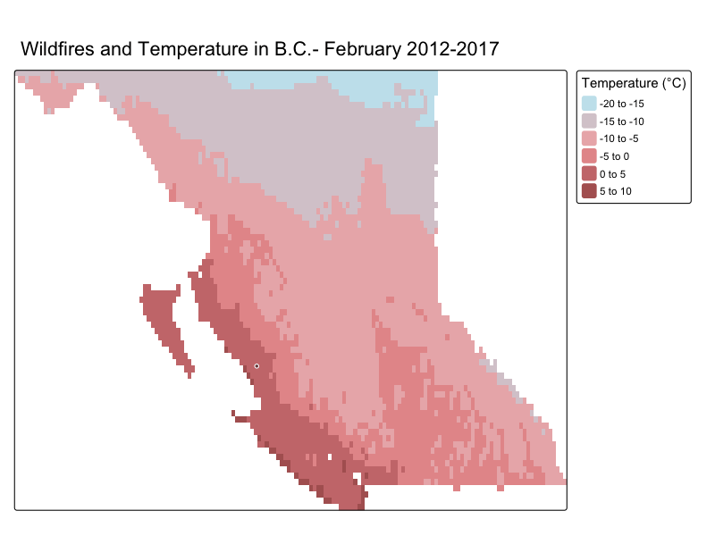

Wildfire Animation

## 3.3 Answer

As the GIF shows, there are no wildfires during the coldest winter months of December and January. Wildfire activity peaks in the summer months of July and August, suggesting a potential relationship between higher temperatures and increased fire occurrence.

# Q4 (a) how do temperature impact fire occurence?

## 4.1 Extract temperature values and assign them to wildfire points

```r
# Initialize the temperature column in wildfire_sf
wildfire_sf$temperature <- NA

# Loop through each month (1 to 12)
for (i in 1:12) {
  # Format the month as '01', '02', ..., '12'
  month_str <- sprintf("%02d", i)

  # Filter fire points for the current month
  monthly_fires <- wildfire_sf %>% filter(Month == month_str)

  # Extract temperature values for the current month from the corresponding layer in temp_data_bc
  if (nrow(monthly_fires) > 0) {  # Only extract if there are fire points for this month
    extracted_temps <- terra::extract(temp_data_bc[[i]], monthly_fires)
    wildfire_sf$temperature[wildfire_sf$Month == month_str] <- as.numeric(extracted_temps[, 2])
  }
}
# Check for NA values
#sum(is.na(wildfire_sf$temperature))
```

## 4.2 Visualization

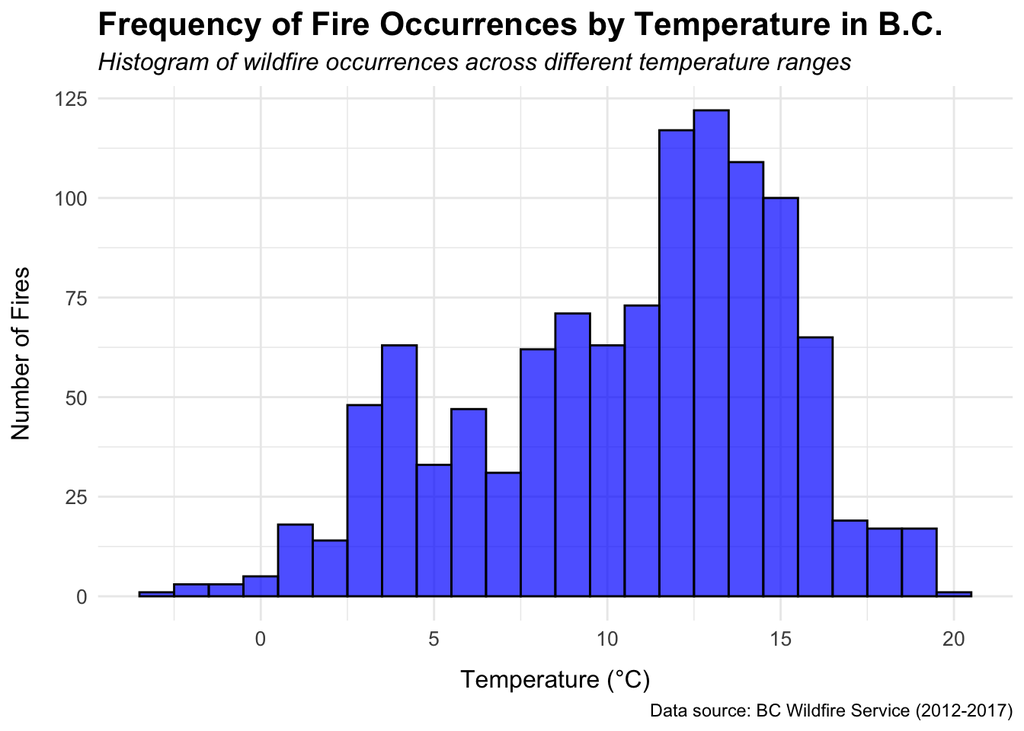

```r
# Histogram plot of fire frequency vs temperature
ggplot(wildfire_sf, aes(x = temperature)) +
  geom_histogram(binwidth = 1, color = "black", fill = "blue", alpha = 0.7) +

  # Titles and descriptions
  labs(
    title = "Frequency of Fire Occurrences by Temperature in B.C.",
    subtitle = "Histogram of wildfire occurrences across different temperature ranges",
    x = "Temperature (°C)",
    y = "Number of Fires",
    caption = "Data source: BC Wildfire Service (2012-2017)"
  ) +

  # Customize theme for better readability
  theme_minimal() +
  theme(
    plot.title = element_text(size = 16, face = "bold"),
    plot.subtitle = element_text(size = 12, face = "italic"),
    axis.text.x = element_text(size = 10),
    axis.text.y = element_text(size = 10),
    axis.title.x = element_text(size = 12, margin = margin(t = 10)),
    axis.title.y = element_text(size = 12, margin = margin(r = 10))
  )
```

## 4.3 Answer:

The plot shows that most wildfires occur within the temperature range of 10 to 15 degrees Celsius. Specifically, the highest number of wildfires is observed at 13 degrees, with over 120 fire incidents. When the temperature is below 0 degrees, wildfire occurrences are rare. As the temperature increases to 10 degrees, the number of fires rises to about 60. However, when the temperature exceeds 15 degrees, the frequency of wildfires drops significantly.

# Q4 (b) how do elevation impact fire occurence?

## 4.4 Extract elevation data for fire points

```r
# Extract elevation data for fire points
wildfire_sf$elevation <- terra::extract(elevation_data_bc, wildfire_sf)[, 2]

# Check for NA values
#sum(is.na(wildfire_sf$elevation))

# Since there is only 1 missing value, and so I will remove it
wildfire_sf <- wildfire_sf |> filter(!is.na(elevation))
```

## 4.5 Visualization for Fire frequency vs Elevation

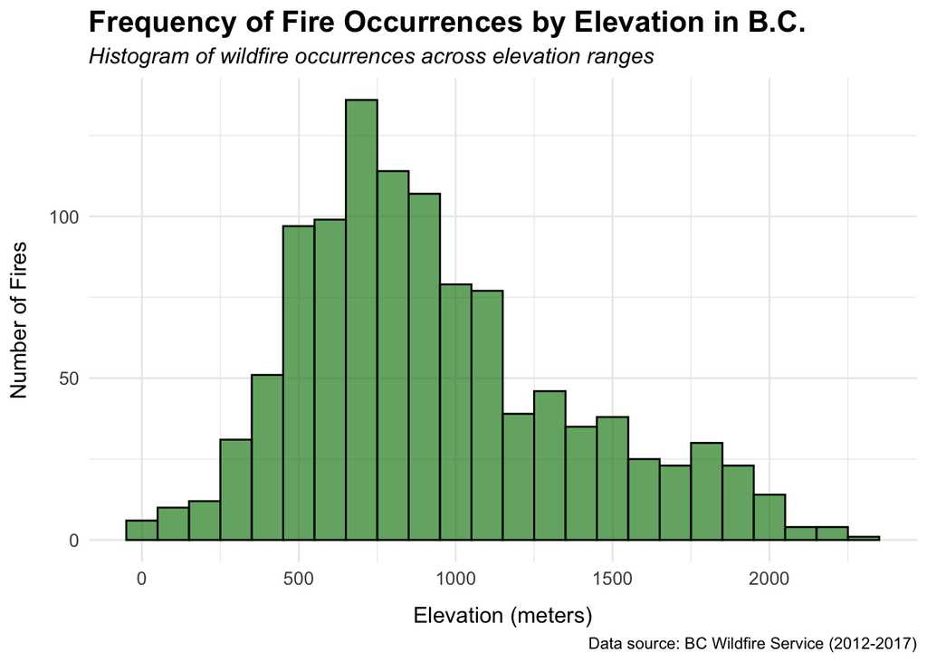

```r
# Histogram plot
ggplot(wildfire_sf, aes(x = elevation)) +
  geom_histogram(binwidth = 100, color = "black", fill = "forestgreen", alpha = 0.7) +
  labs(
    title = "Frequency of Fire Occurrences by Elevation in B.C.",
    subtitle = "Histogram of wildfire occurrences across elevation ranges",
    x = "Elevation (meters)",
    y = "Number of Fires",
    caption = "Data source: BC Wildfire Service (2012-2017)"
  ) +
  theme_minimal() +
  theme(
    plot.title = element_text(size = 16, face = "bold"),
    plot.subtitle = element_text(size = 12, face = "italic"),
    axis.text.x = element_text(size = 10),
    axis.text.y = element_text(size = 10),
    axis.title.x = element_text(size = 12, margin = margin(t = 10)),
    axis.title.y = element_text(size = 12, margin = margin(r = 10))
  )
```

# Q5 How does the historical distribution (2012-2017) of wildfires differ from this year’s (2024) wildfires?

```r
#Load the 2024 wildfire data from website
data_24 <- read.csv("/Users/zimoyang/Downloads/BCGW_7113060B_1730755050790_21852/PROT_CURRENT_FIRE_PNTS_SP/C_FIRE_PNT.csv")
```

## 5.1 Data Preprocessing

```r
#Get a sense of the data structure and data types
#head(data_24)
#summary(data_24)
#str(data_24)

#Subset the data by selecting specific columns to match the data_1217.
wildfire_24 <- data_24[, c("IGN_DATE", "FIRE_YEAR", "LATITUDE", "LONGITUDE", "SIZE_HA", "FIRE_NO", "FIRE_CENTR", "GEO_DESC")]

#Handling missing data
#colSums(is.na(wildfire_24))          # No missing data

#Handling duplicates
#sum(duplicated(wildfire_24))        # No duplicates

#Transform the date
wildfire_24 <- wildfire_24 %>%
  mutate(
    IGN_DATE = IGN_DATE / 1e10
  )

#Check if the date is transformed correctly
#summary(wildfire_24)

#Handling outliers
#summary(wildfire_24$SIZE_HA)
#boxplot(wildfire_24$SIZE_HA, main="Distribution of Size")

#summary(wildfire_24$IGN_DATE)
#boxplot(wildfire_24$IGN_DATE, main="Distribution of Discovery date")

# Correct the outliers by multiplying them by 1e6 and create the Year and Month cloumns
wildfire_24 <- wildfire_24 %>%
  mutate(
    IGN_DATE = ifelse(IGN_DATE < 1, IGN_DATE * 1e6, IGN_DATE),
    Year = as.integer(IGN_DATE),
    Month = as.integer(round((IGN_DATE %% 1) * 100))
  )

# Filter the dataset to include only records from 2024
wildfire_24 <- wildfire_24 %>%
  filter(Year == 2024)
```

## 5.2 Answer:

1. Since we will be comparing the distribution of the two data sets, I will subset the 2024 data by selecting columns to match the data from 2012-2017. Please Note: I am choosing IGN_DATE because it is the date of ignition which is similar to the idea of discover date in the data set from 2012-2017
2. There is no missing value and duplicate data in the data set.
3. There are some outliers for the Ignition Dates (IGN_DATE) from 2022, since this data set only include data from 2024, I will remove the outlier dates.
4. Similar to fire size from the data 2012-2017, there are some outliers here but I will not remove them because they are valid points

## 5.3 Data preparation

```r
# Step 1: Prepare the Historical Data (2012-2017)
wildfire_sf$Year <- as.integer(wildfire_sf$Year)
wildfire_sf$Month <- as.integer(wildfire_sf$Month)

# Step 2: Aggregate Monthly Statistics for Historical Data
historical_monthly <- wildfire_sf %>%
  group_by(Month) %>%
  summarise(
    Frequency = n(),
    Avg_Size = mean(`Size (ha)`, na.rm = TRUE)
  )

# Step 3: Add the missing month: Create a data frame for January and December with zero fire frequency and size
missing_months <- data.frame(
  Month = c(1, 12),
  Frequency = c(0, 0),
  Avg_Size = c(0, 0)
)

# Step 4: Add the missing months to the historical_monthly data
historical_monthly <- historical_monthly %>%
  bind_rows(missing_months) %>%
  arrange(Month)

# Print the updated historical_monthly data
#print(historical_monthly)

# Step 5: Prepare the Current Year (2024) Data
wildfire_24$Year <- as.integer(wildfire_24$Year)
wildfire_24$Month <- as.integer(wildfire_24$Month)

# Aggregate Monthly Statistics for 2024 Data
current_monthly <- wildfire_24 %>%
  group_by(Month) %>%
  summarise(
    Frequency = n(),
    Avg_Size = mean(`SIZE_HA`, na.rm = TRUE)
  )
```

## Visualization to Compare Fire Frequency and Average Fire size

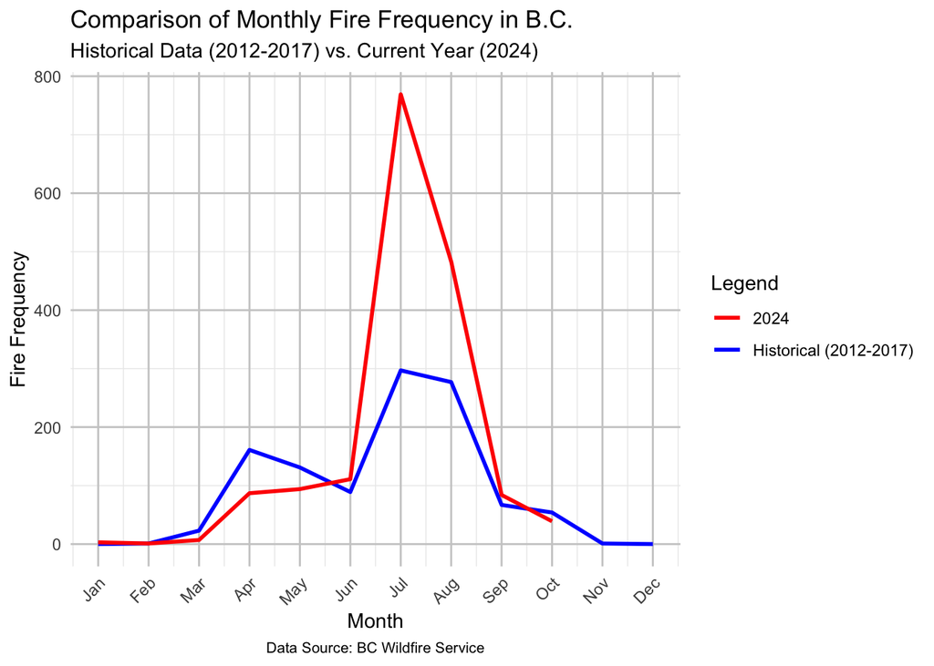

```r
# Create a vector of month names for x-axis labels
month_labels <- c("Jan", "Feb", "Mar", "Apr", "May", "Jun",
                  "Jul", "Aug", "Sep", "Oct", "Nov", "Dec")

# Step 1: Plot the Comparison of Fire Frequency
ggplot() +
  geom_line(data = historical_monthly, aes(x = Month, y = Frequency, color = "Historical (2012-2017)"), size = 1) +
  geom_line(data = current_monthly, aes(x = Month, y = Frequency, color = "2024"), size = 1) +
  scale_x_continuous(breaks = 1:12, labels = month_labels) +
  scale_color_manual(values = c("Historical (2012-2017)" = "blue", "2024" = "red")) +
  labs(title = "Comparison of Monthly Fire Frequency in B.C.",
       subtitle = "Historical Data (2012-2017) vs. Current Year (2024)",
       x = "Month",
       y = "Fire Frequency",
       color = "Legend",
       caption = "Data Source: BC Wildfire Service") +
  theme_minimal() +
  theme(
    panel.grid.major = element_line(color = "grey80"),
    axis.text.x = element_text(angle = 45, hjust = 1),
    plot.caption = element_text(hjust = 0.5, size = 8)
  )
```

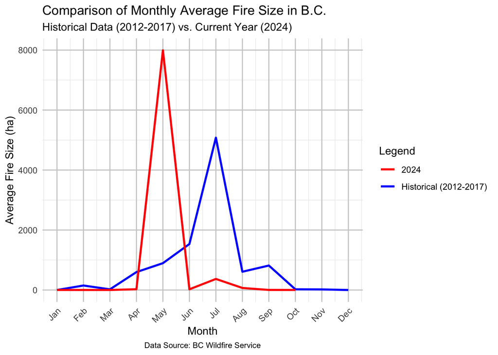

```r
# Step 2: Plot the Comparison of Average Fire Size
ggplot() +
  geom_line(data = historical_monthly, aes(x = Month, y = Avg_Size, color = "Historical (2012-2017)"), size = 1) +
  geom_line(data = current_monthly, aes(x = Month, y = Avg_Size, color = "2024"), size = 1) +
  scale_x_continuous(breaks = 1:12, labels = month_labels) +
  scale_color_manual(values = c("Historical (2012-2017)" = "blue", "2024" = "red")) +
  labs(title = "Comparison of Monthly Average Fire Size in B.C.",
       subtitle = "Historical Data (2012-2017) vs. Current Year (2024)",
       x = "Month",
       y = "Average Fire Size (ha)",
       color = "Legend",
       caption = "Data Source: BC Wildfire Service") +
  theme_minimal() +
  theme(
    panel.grid.major = element_line(color = "grey80"),
    axis.text.x = element_text(angle = 45, hjust = 1),
    plot.caption = element_text(hjust = 0.5, size = 8)
  )
```

## 5.3 Statistical Test

## 5.3a Check for Normality

```r
# Step 1: Prepare Data for Statistical Tests
historical_frequency <- historical_monthly$Frequency
current_frequency <- current_monthly$Frequency

historical_size <- historical_monthly$Avg_Size
current_size <- current_monthly$Avg_Size

# Step 2: Check Normality Using Shapiro-Wilk Test
shapiro_historical_freq <- shapiro.test(historical_frequency)
shapiro_current_freq <- shapiro.test(current_frequency)

shapiro_historical_size <- shapiro.test(historical_size)
shapiro_current_size <- shapiro.test(current_size)

# Print Shapiro-Wilk Test Results
#cat("Shapiro-Wilk Test for Normality:\n")
print(shapiro_historical_freq)
```

```
    Shapiro-Wilk normality test

data:  historical_frequency
W = 0.83026, p-value = 0.02113
```

```r
print(shapiro_current_freq)
```

```
    Shapiro-Wilk normality test

data:  current_frequency
W = 0.67877, p-value = 0.0004876
```

```r
print(shapiro_historical_size)
```

```
    Shapiro-Wilk normality test

data:  historical_size
W = 0.60637, p-value = 0.0001213
```

```r
print(shapiro_current_size)
```

```
    Shapiro-Wilk normality test

data:  current_size
W = 0.39288, p-value = 2.064e-07
```

## 5.3b Run Mann-Whitney U test due to non-normal distribution

```r
# Step 3: Choose Statistical Test Based on Normality
# For Monthly Fire Frequency
if (shapiro_historical_freq$p.value > 0.05 & shapiro_current_freq$p.value > 0.05) {
  # Use T-test if both datasets are normally distributed
  freq_test <- t.test(historical_frequency, current_frequency, alternative = "two.sided")
} else {
  # Use Mann-Whitney U test if data is not normally distributed
  freq_test <- wilcox.test(historical_frequency, current_frequency, alternative = "two.sided")
}
# For Average Fire Size
if (shapiro_historical_size$p.value > 0.05 & shapiro_current_size$p.value > 0.05) {
  # Use T-test if both datasets are normally distributed
  size_test <- t.test(historical_size, current_size, alternative = "two.sided")
} else {
  # Use Mann-Whitney U test if data is not normally distributed
  size_test <- wilcox.test(historical_size, current_size, alternative = "two.sided")
}
# Step 4: Print the Test Results
cat("\nStatistical Test Results for Monthly Fire Frequency:\n")
```

```
Statistical Test Results for Monthly Fire Frequency:
```

```r
print(freq_test)
```

```
    Wilcoxon rank sum test with continuity correction

data:  historical_frequency and current_frequency
W = 50, p-value = 0.5305
alternative hypothesis: true location shift is not equal to 0
```

```r
cat("\nStatistical Test Results for Average Fire Size:\n")
```

```
Statistical Test Results for Average Fire Size:
```

```r
print(size_test)
```

```
    Wilcoxon rank sum test with continuity correction

data:  historical_size and current_size
W = 78, p-value = 0.2484
alternative hypothesis: true location shift is not equal to 0
```

## 5.3c Permutaion test due to ties

As the results shown in fire frequency comparison, the Wilcoxon rank sum exact test cannot compute exact p-value with ties, I will use permutation test to resolve this issue

```r
# Step 1: Combine the Data into a Single Data Frame
combined_frequency <- data.frame(
  Frequency = c(historical_frequency, current_frequency),
  Group = factor(c(rep("Historical", length(historical_frequency)),
                   rep("Current", length(current_frequency))))
)

# Step 2: Perform the Permutation Test
freq_test_perm <- wilcox_test(Frequency ~ Group, data = combined_frequency, distribution = "approximate")

# Step 3: Print the Test Result
cat("Permutation Test Results for Monthly Fire Frequency (Feb-Oct):\n")
```

```
Permutation Test Results for Monthly Fire Frequency (Feb-Oct):
```

```r
print(freq_test_perm)
```

```
    Approximative Wilcoxon-Mann-Whitney Test

data:  Frequency by Group (Current, Historical)
Z = 0.66031, p-value = 0.5345
alternative hypothesis: true mu is not equal to 0
```

## 5.4 Answer

From the fire frequency plot, the wildfire frequency for 2024 (red line) is significantly higher than the historical data (blue line) during the peak months (July and August). Both lines show minimal fire activity from January to March and from October to December, consistent with typical seasonal wildfire trends.

However, at the 0.05 significance level, a comparison between the historical wildfire data (2012-2017) and the current data from 2024 shows no statistically significant difference in fire frequency and average fire size.

## Q6 Data/analysis Limitation

Since 2024 is the current year, we don’t yet have wildfire data for November and December, which limits our analysis of late-year trends and comparisons with historical data. Additionally, wildfire reporting has changed significantly over the past decade. In addition, for the comparison between historical and current wildfire data distribution, due to non-normal data distributions, parametric tests like the T-test were not suitable for this analysis. Instead, non-parametric tests (e.g., Mann-Whitney U test) were used, which are less powerful and may have reduced sensitivity when detecting differences between groups. Lastly, the analysis primarily focused on temperature and elevation, excluding other important factors like wind speed, humidity, and vegetation type. This simplification may overlook key environmental influences on wildfire behavior.